# `standardanalysis` tutorial

## Introduction

This tutorial demonstrates how to use the `standardanalysis` package in R for routine microbiome data analysis. `standardanalysis` provides a range of functions to streamline your workflow, from data import and preprocessing to diversity analysis, differential abundance testing, and statistical modeling.

The package offers the following functions:

- **Data Import and Preprocessing:**
  - `import_data`: Import BIOM and mapping file and merge into a `phyloseq` object.
  - `clean_taxonomy`: Clean and standardize taxonomic assignments.
  - `remove_unwanted_samples`: Remove unwanted samples based on sample IDs.
  - `rarefy_single`: Perform single rarefaction (subsampling) of a phyloseq object.
- **Diversity analysis: multiple subsampling (rarefaction) workflow**
  - `rarefy_multiple`: Create multiple rarefied phyloseq objects for assessing variance.
  - `calculate_alpha_df`: Calculate alpha-diversity metrics for multiple rarefied objects.
  - `calculate_average_alpha_ps`: Calculate average alpha-diversity across rarefactions.
  - `multiple_test_alpha`: Test for differences in alpha-diversity across multiple rarefactions.
  - `multiple_permanova`: Run PERMANOVA on multiple rarefied objects to assess community differences.
  - `permanova_average`: Aggregate and summarize PERMANOVA results across rarefactions.
  - **Visualization:**
  - `barplot_abundance`: Generate stacked barplots of taxonomic abundances.
  - `make_pca`: Perform Principal Component Analysis (PCA) and generate ordination plots.
  - `make_heatmap`: Generate heatmaps of microbial taxa.
- **Community Composition and Differential Abundance:**
  - `run_ancombc2`: Run differential abundance analysis using ANCOMBC-2.
  - `display_ancombc2_results`: Display ANCOMBC-2 in optionally interactive tables.

Most functions in `standardanalysis` (except `permanova_average` and differential abundance analysis functions) support **parallel** execution using the [`future`](https://future.futureverse.org/) framework. This allows you to speed up computation by distributing the load across multiple CPU cores or nodes, which is especially useful for large datasets or high-performance computing (HPC) environments.

## Prerequisites

Before you begin, make sure you have the following packages installed:

```r
options(repos = c(CRAN = "https://cloud.r-project.org"))
requirements <- c("devtools", "BiocManager", "future.apply")
for (package in requirements) {
    if (!requireNamespace(package, quietly = TRUE)) {
        install.packages(package)
        if (package == "BiocManager") {
            BiocManager::install(c("phyloseq", "microbiome"))
        }
    }
}
```

## Loading packages

```r
library(standardanalysis)
```

## Setting up Parallelization

```r
future::plan("multisession", workers = parallel::detectCores() - 1)
```

You can control the number of parallel workers with the `workers` argument (or `mc.cores` for some backends). For more information on available parallelization strategies and how to choose the best plan for your system (e.g., multicore, cluster, etc.), see the [future plan documentation](https://future.futureverse.org/reference/plan.html).

**For reproducible analyses in parallel, set the random number generator kind to L’Ecuyer-CMRG:**

```r
base::RNGkind(kind = "L'Ecuyer-CMRG")  # for parallel RNG
```

# Microbiome data analysis in R

## Input data

Let’s start by loading your data: change the following variables to your directory and file names. It is useful to declare your treatment variable already because most examples use the “treatment_variable” already so then you dont have to change anything. Optionally set your working directory to save results in same (parent) folder.

```r
input_directory <- "Path/to/your/data"
biom_file_name <- "test_biom_water.biom"
mapping_file_name <- "test_mapping_file.txt"
treatment_variable <- "Source"

# setwd(input_directory)
```

#### Import the BIOM and mapping file.

You can specify the metadata variables to be parsed as factors in the `factors` argument of `import_data`. Passing no arguments to the function will load the mock dataset, as here, for demonstration purposes.

```r
# ps <- import_data(biom_file_name, mapping_file_name, factors = 'Source')
ps <- import_data()
> Time to complete depends on OTU file size

# Function for cleaning up taxonomy
ps <- clean_taxonomy(ps)
```

## Normalizing the library sizes (Rarefying)

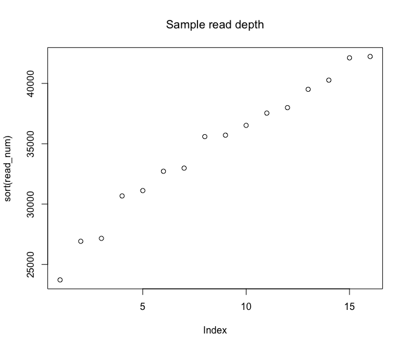

```r
read_num <- phyloseq::sample_sums(ps)
print(sort(read_num))
> MB.30.NP.0.MB.DNA055 MB.30.NP.0.MB.DNA054 MB.30.NP.0.MB.DNA053
>                23719                26919                27161
> MB.30.NP.0.MB.DNA051  MB.30.P.0.MB.DNA063 MB.30.NP.0.MB.DNA050
>                30676                31120                32720
> MB.30.NP.0.MB.DNA049 MB.30.NP.0.MB.DNA056  MB.30.P.0.MB.DNA060
>                32982                35594                35712
>  MB.30.P.0.MB.DNA057  MB.30.P.0.MB.DNA059 MB.30.NP.0.MB.DNA052
>                36524                37539                37995
>  MB.30.P.0.MB.DNA062  MB.30.P.0.MB.DNA061  MB.30.P.0.MB.DNA064
>                39511                40272                42120
>  MB.30.P.0.MB.DNA058
>                42231
plot(sort(read_num), main = "Sample read depth")
```

## Plotting rarecurve

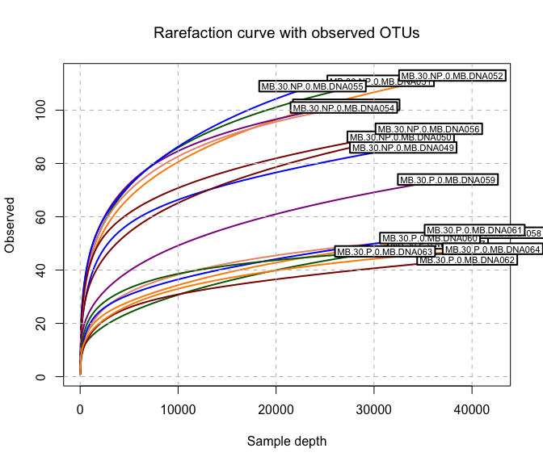

```r
rare_curve(ps, label = T)
```

## Removing unwanted sample(s)

```r
unwanted_samples <- c("MB.30.NP.0.MB.DNA048")  # replace with your own sample names
ps <- phyloseq::subset_samples(ps, !X.SampleID %in% unwanted_samples)

# Check if the right ones are removed
microbiome::meta(ps)$X.SampleID
>  [1] "MB.30.NP.0.MB.DNA049" "MB.30.NP.0.MB.DNA050" "MB.30.NP.0.MB.DNA051"
>  [4] "MB.30.NP.0.MB.DNA052" "MB.30.NP.0.MB.DNA053" "MB.30.NP.0.MB.DNA054"
>  [7] "MB.30.NP.0.MB.DNA055" "MB.30.NP.0.MB.DNA056" "MB.30.P.0.MB.DNA057"
> [10] "MB.30.P.0.MB.DNA058"  "MB.30.P.0.MB.DNA059"  "MB.30.P.0.MB.DNA060"
> [13] "MB.30.P.0.MB.DNA061"  "MB.30.P.0.MB.DNA062"  "MB.30.P.0.MB.DNA063"
> [16] "MB.30.P.0.MB.DNA064"
```

## Rarefaction of samples

```r
ps_rare <- rarefy_single(ps, depth = 0, mc = 1000)
> [1] "You chose not to rarefy. Samples with less than mc will be removed."
```

## Calculating the diversity and plotting samples.

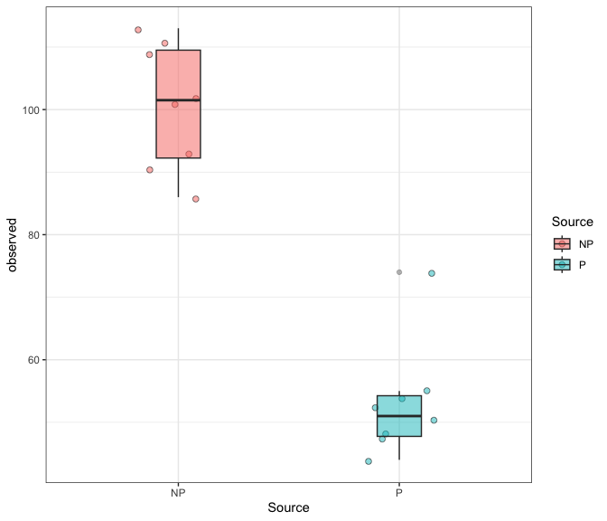

```r
alpha_boxplot(ps_rare, x_grp = treatment_variable, a_index = "observed", na.rm = T)
```

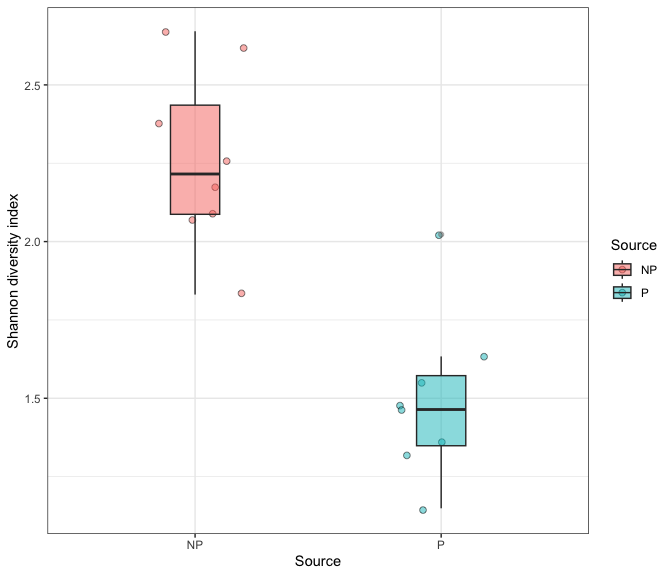

```r
alpha_boxplot(ps_rare, x_grp = treatment_variable, a_index = "diversity_shannon") +
    ggplot2::ylab("Shannon diversity index")
```

## Multiple rarefaction

As an alternative to rarefying a phyloseq object once, here, we will perform rarefaction over multiple phyloseq objects. The idea is that it should give us an estimate of the variance in rarefied phyloseq objects that we would not be able to see from a single rarefied phyloseq object.

### Workflow overview

The main steps in the workflow are:

1. **rarefy_multiple**: Create multiple rarefied versions of your phyloseq object.
2. **calculate_alpha_df**: Calculate alpha-diversity metrics for each rarefied object.
3. **calculate_average_alpha_ps**: Summarize alpha-diversity metrics across rarefactions.
4. **multiple_test_alpha**: Test for group differences in alpha-diversity across rarefactions.
5. **multiple_permanova**: Run PERMANOVA on each rarefied object to assess group differences in community composition.
6. **permanova_average**: Aggregate and summarize PERMANOVA results across rarefactions.

### Making a list of rarefied phyloseq objects

You can choose your sample size for rarefaction and the amount of rarefied phyloseq objects that you want to create.

```r
ps_list <- rarefy_multiple(ps, sample.size = 2000, iter = 10)
```

### Diversity testing with multiple rarefaction

```r
alpha_df <- calculate_alpha_df(ps_list, measures = c("Shannon", "Simpson", "Chao1"))

ps_multi_ss <- phyloseq::subset_samples(ps, microbiome::meta(ps)$X.SampleID %in%
    unique(alpha_df$X.SampleID))
phyloseq::sample_data(ps_multi_ss) <- cbind(phyloseq::sample_data(ps_multi_ss), calculate_average_alpha_ps(alpha_df))
```

### Plotting diversity for multiple rarefaction

You can aggregate the p-values with the Aggregated Cauchy Association test (ACAT) using the `acat` function.

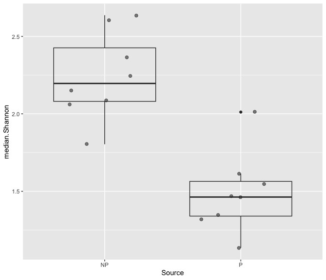

```r
microbiome::boxplot_abundance(ps_multi_ss, x = treatment_variable, y = "median.Shannon")
```

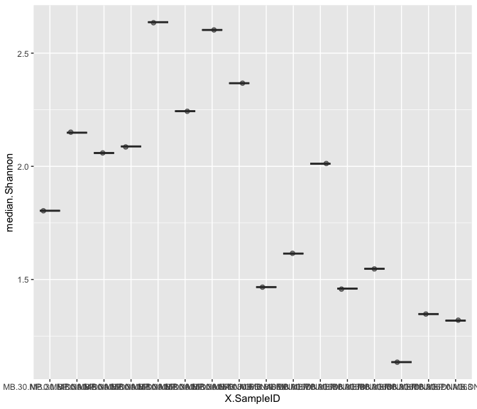

```r
microbiome::boxplot_abundance(ps_multi_ss, x = "X.SampleID", y = "median.Shannon")
```

```r
# Note that you dont use average values here but 'raw' alpha-div
mt_alpha <- multiple_test_alpha(alpha_df, pseq = ps_multi_ss, alpha_div = "Shannon",
    variable = treatment_variable, method = "wilcox.test")


# median(x), mean(X), summary(x), min(x) (minimum) For example - using the
# above:
median(mt_alpha)
> [1] 0.0003108003

# Performing ACAT
acat(mt_alpha)
> [1] 0.0003453337
```

### PERMANOVA Across Multiple Rarefied Datasets

PERMANOVA (Permutational Multivariate Analysis of Variance) is a widely used method to test for differences in community composition between groups based on distance matrices. In R, this is typically performed with the `adonis2` function from the `vegan` package, and is commonly used in microbiome data analysis workflows with `phyloseq` objects.

#### Running PERMANOVA on Multiple Rarefied Phyloseq Objects

The function `multiple_permanova()` allows you to run PERMANOVA on each rarefied version of your phyloseq object, making it possible to assess the consistency of your results across random subsamplings.

Key features: - **Input:** A list of rarefied phyloseq objects (e.g., from `rarefy_multiple()`). - **Dissimilarity Index:** Supports all metrics accepted as `method` by `vegan::vegdist()`, `"manhattan"`, `"euclidean"`, `"canberra"`, `"clark"`, `"bray"`, `"kulczynski"`, `"jaccard"`, `"gower"`, `"altGower"`, `"morisita"`, `"horn"`, `"mountford"`, `"raup"`, `"binomial"`, `"chao"`, `"cao"`, `"mahalanobis"`, `"chisq"`, `"chord"`, `"hellinger"`, `"aitchison"`, or `"robust.aitchison"`. - **Multiple variables:** You can test one or more metadata variables (e.g., `"Group"` or `"Var1 + Var2"`). - **Longitudinal/stratified designs:** By specifying the `longit` argument, you can account for repeated measures or paired samples. - **Aitchison support:** When using `"aitchison"` distance, a pseudocount is added to each OTU table. - **Parallelization:** The function uses `future.apply::future_lapply()` for efficient parallel computation.

**Example usage:**

```r
adonis_results <- multiple_permanova(
  ps_list,
  distance = "bray",
  variable = "Readdepth + DNA_Conc",
  permutations = 999,
  # longit = "Source",
  ps_ref = NULL # Provide a phyloseq object
)
> Warning in multiple_permanova(ps_list, distance = "bray", variable = "Readdepth + DNA_Conc", : Using Bray-Curtis distance.
>     Data are not log2-transformed in this function.
> Warning in multiple_permanova(ps_list, distance = "bray", variable = "Readdepth + DNA_Conc", : Testing without strata a.k.a.
>     testing with cross-sectional design.
```

The output is a list of `adonis2` results, one for each rarefied dataset. This allows you to check whether your findings are robust to random subsampling, which is important in microbiome studies where library size can influence diversity and composition estimates.

#### Aggregating and Visualizing PERMANOVA Results

Once you have run PERMANOVA across all rarefied datasets, you can use `permanova_average()` to summarize and visualize the results.

What `permanova_average()` provides: - The median (or other summary) of the pseudo-F statistics across rarefactions. - The interquartile range (IQR) of the pseudo-F statistics. - The median (or other summary) of the PERMANOVA p-values. - An aggregated p-value using the ACAT method, which combines all p-values into a single significance value. - Boxplots visualizing the distribution of pseudo-F statistics and p-values, with the ACAT p-value highlighted.

**Example usage:**

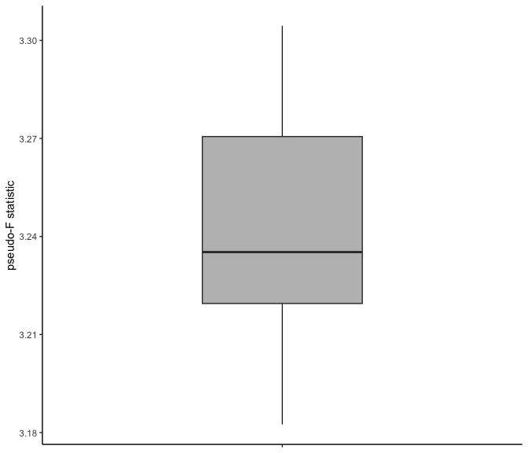

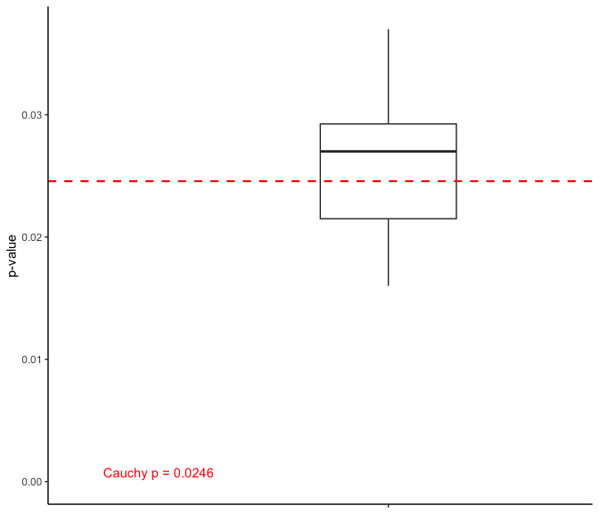

```
> $F.median
> [1] 3.2
>
> $F.IQR
> [1] "3.2 - 3.3"
>
> $p.median
> [1] 0.027
>
> $p.Cauchy
> [1] 0.02456631
>
> $Fvals
>  [1] 3.304514 3.282332 3.268737 3.234266 3.225136 3.213908 3.236189 3.271198
>  [9] 3.217615 3.182478
>
> $pvals
>  [1] 0.037 0.023 0.034 0.030 0.027 0.019 0.027 0.016 0.027 0.021
```

```r
permanova_average(adonis_results)
```

## Plotting abundance graph

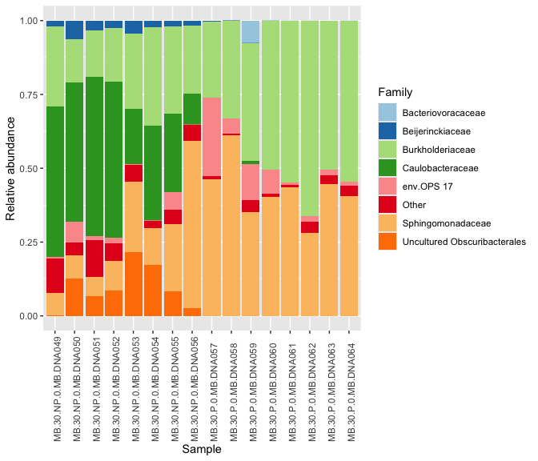

```r
# https://microbiome.github.io/tutorials/Composition.html Give taxonomic level,
# detection, prevalence.

# Optional to split plot by a variable: use 'group_by = treatment_variable

# For grouping more than two variables, use outside of the function: +
# facet_wrap(Var1~Var2, scales = 'free_x') or alternatively for nested-groups +
# facet_wrap(~Var1 + Var2, scales = 'free_x')

barplot_abundance(ps, level = "Family", detection = 5/100, prevalence = 0/nrow(microbiome::meta(ps)))  #+ facet_wrap(~My_grouping_variable + My_other_grouping_variable, scales = 'free_x')
```

## Performing a PCA, and making of ordination plot.

Samples are coloured by treatment variable, default transformation is centered log ratio (CLR). Pseudo-count (shift) is + 1 for all log-transformations

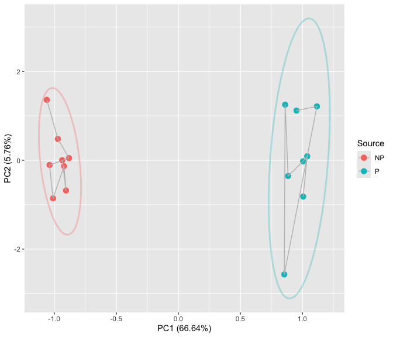

```r
# Optional to also give a different shape to points based on a variable: shape
# = 'My_other_variable'
make_pca(ps, colour_by = treatment_variable, ellipse = T, longi_lines = "Source")
```

## Heatmap

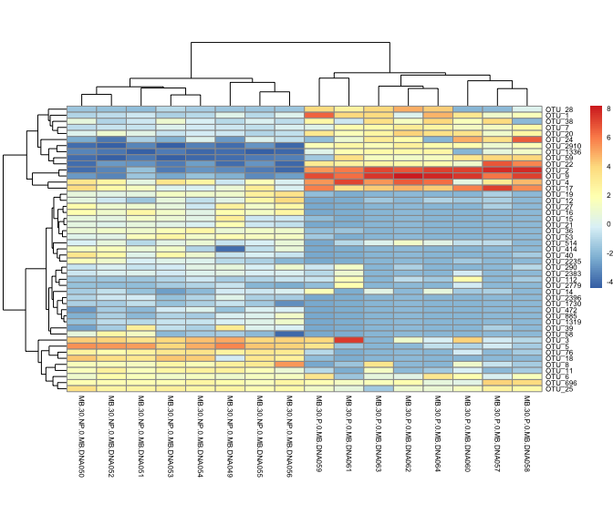

```r
make_heatmap(ps, detection = 7, prevalence = 0.4)
```

```r
# If this plot is too big to be shown properly, you can try copying the line
# with 'heatmap_make(...)' and paste it in the console-window down below this
# window.  Do play around with the detection and prevalence, these defaults are
# just values that worked with the test data: detection = 7, prevalence = 0.4
```

## PERMANOVA

### Unpaired / independent

The following is a PERMANOVA for unpaired or independent samples. You can subset as follows (for example):

```r
ps_subset_sick65 <- phyloseq::subset_samples(ps, HealthStatus == "Sick" & age > 65)
```

Remember that subsetting decreases your per-group sample size. In case you want to transform your data (i.e. CLR), now is a good time for that. Here I use a pseudocount of 1.

```r
ps_shift <- microbiome::transform(ps, transform = "shift", shift = 1)
ps_clr <- microbiome::transform(ps_shift, transform = "clr")


vegan::adonis2(as.formula(paste("phyloseq::distance(phyloseq::otu_table(ps_clr), method = 'euclidean') ~",
    treatment_variable)), data = microbiome::meta(ps_clr), permutations = 9999)
> Permutation test for adonis under reduced model
> Permutation: free
> Number of permutations: 9999
>
> vegan::adonis2(formula = as.formula(paste("phyloseq::distance(phyloseq::otu_table(ps_clr), method = 'euclidean') ~", treatment_variable)), data = microbiome::meta(ps_clr), permutations = 9999)
>          Df SumOfSqs      R2      F Pr(>F)
> Model     1   3581.8 0.66247 27.478  3e-04 ***
> Residual 14   1824.9 0.33753
> Total    15   5406.7 1.00000
> ---
> Signif. codes:  0 '***' 0.001 '**' 0.01 '*' 0.05 '.' 0.1 ' ' 1
```

### Paired / longitudinal

In case you want to perform paired PERMANOVA, you have to assign the variable wherein you want to restrict permutations. This can be something like PatientID, Sample_location etc. Note that if it says in the output “permutation: free”, something went wrong and you did not actually restrict the permutations.

```r
longitudinal_variable <- ""

perm <- permute::how(nperm = 9999)
dat <- microbiome::meta(ps_clr)
permute::setBlocks(perm) <- with(dat, microbiome::meta(ps_clr)[[longitudinal_variable]])

vegan::adonis2(as.formula(paste("phyloseq::distance(phyloseq::otu_table(ps_clr), method='euclidean') ~",
    treatment_variable)), data = dat, permutations = perm)
> Permutation test for adonis under reduced model
> Permutation: free
> Number of permutations: 9999
>
> vegan::adonis2(formula = as.formula(paste("phyloseq::distance(phyloseq::otu_table(ps_clr), method='euclidean') ~", treatment_variable)), data = dat, permutations = perm)
>          Df SumOfSqs      R2      F Pr(>F)
> Model     1   3581.8 0.66247 27.478  3e-04 ***
> Residual 14   1824.9 0.33753
> Total    15   5406.7 1.00000
> ---
> Signif. codes:  0 '***' 0.001 '**' 0.01 '*' 0.05 '.' 0.1 ' ' 1
```

## Differential abundance analysis

# ALDEx2

The ALDEx2 authors recommend 128 or more mc.samples for the t-test, 1000 for a rigorous effect size calculation, and at least 16 for ANOVA. Try a low amount (16) first and then later change if it runs like it should. Effect size confidence interval: The authors find that the SAFEST approach is to identify those features that where the 95% CI of the effect size does not cross 0. As for effect size threshold, in the ALDEx2 vignettes paragraph 5.3 the authors state the following: “We suggest that an effect size cutoff of 1 or greater be used when analyzing HTS datasets. If preferred the user can also set a fold-change cutoff as is commonly done with P value based methods.” For the ALDEx2 results, see the vignette: https://www.bioconductor.org/packages/devel/bioc/vignettes/ALDEx2/inst/doc/ALDEx2_vignette.html

```r
# Calculating instances and clr transform
x <- ALDEx2::aldex.clr(as.data.frame(phyloseq::otu_table(ps)), microbiome::meta(ps)[[treatment_variable]],
    mc.samples = 128, denom = "all", verbose = TRUE)

# Testing
x.tt <- ALDEx2::aldex.ttest(x, paired.test = FALSE, verbose = FALSE)
x.effect <- ALDEx2::aldex.effect(x, CI = TRUE, verbose = FALSE, paired.test = FALSE)

# Plotting
x.all <- data.frame(x.tt, x.effect)
par(mfrow = c(1, 2))
ALDEx2::aldex.plot(x.all, type = "MA", all.pch = 19, all.cex = 0.4, called.col = "red",
    called.pch = 20, called.cex = 0.6, thres.line.col = "darkgrey", thres.lwd = 1.5,
    test = "welch", rare.col = "black", rare = 0, rare.pch = 20, rare.cex = 0.2)
ALDEx2::aldex.plot(x.all, type = "MW", test = "welch")

# Effect interval does not cross 0, has effect > 1 (or -1), has significant
# test with error correction
x.all_sign <- subset(x.all, (x.all$effect.low > 0 & x.all$effect.high > 0) | (x.all$effect.low <
    0 & x.all$effect.high < 0) | abs(x.all$effect) > 1 | x.all$wi.eBH <= 0.05)

# I will print only the columns that are more interesting
x.all_int <- x.all_sign[-c(1, 2, 5:9, 13)]

# Sorting on effect size
print(x.all_int[order(abs(x.all_int$effect), decreasing = TRUE), ])
```

# ANCOM-BC2

```r
params <- list(
  # Model formula parameters
  fixed_terms = "Timepoint + SubjectID", # Fixed effects formula
  random_terms = "(Timepoint | SubjectID)", # Random effects formula
  grouping_variable = NULL, # Grouping variable

  # General parameters
  n_cores = 16, # Number of CPU cores or clusters
  verbose = TRUE, # Verbose output

  # Preprocessing parameters
  taxonomy_level = NULL, # Taxonomic level to be tested
  prevalence_cutoff = 0.1, # Prevalence cut-off
  library_size_cutoff = 1000, # Library size cut-off

  # Structural zeros parameters
  structural_zero = TRUE, # Detect structural zeros
  lower_bound = TRUE, # Classify a taxon as a structural zero using its asymptotic lower bound

  # Statistical parameters
  p_adj_method = "holm", # P-value (multiple testing) adjustment method
  alpha = 0.05, # Significance level
  iter = 10, # Number of REML AND EM iterations
  bootstrap = 10, # Number of bootstrap samples, should be 100+

  # Multi-group test parameters: set to FALSE if no grouping_variable!
  global = TRUE, # Perform global test
  pairwise = TRUE, # Perform pairwise tests
  dunnet = TRUE, # Perform Dunnett's test
  trend = TRUE, # Perform trend test

  # Pseudocount sensitivity analysis parameters
  pseudo_sens = TRUE, # Sensitivity analysis
  s0_perc = 0.05 # -th percentile of std. error values for each fixed effect (microarray sig.- SAM)
)

out <- run_ancombc2(
  ps = ps,
  params = params
)
display_ancombc2_results(out, selected_results = c("global", "trend"))
```

# Maaslin2

```r
# For both the asv/otu table as well as meta data
otu <- t(phyloseq::otu_table(ps))
meta_data <- data.frame(microbiome::meta(ps))

# You can specifiy different GLMs/normalizations/transforms. These are
# according to Nearing 2021 settings.
fit_data <- Maaslin2::Maaslin2(otu, meta_data, output = "My_maaslin2_analysis", transform = "AST",
    fixed_effects = treatment_variable, normalization = "TSS", )

res_ms2 <- fit_data$results
res_ms2_clean <- subset(res_ms2, res_ms2$qval <= 0.05)
res_ms2_int <- res_ms2_clean[-c(2, 3, 5, 7, 9, 10)]
print(res_ms2_int)
```

# Intersection of OTUs found differentially abundant by all three methods

```r
sign_aldex <- rownames(x.all_int)
sign_ancom <- res_anc_int[, 1]
sign_maaslin2 <- res_ms2_int[, 1]

sign_3 <- intersect(sign_aldex, intersect(sign_ancom, sign_maaslin2))
as.data.frame(tax_table(ps)[sign_3, -c(1:4)])
```